# Hardy-Weinberg Equilibrium

EFB 696 - Population Ecology

2026-01-15

# Background

Hardy-Weinberg Equilibrium (HWE) describes the expected genotype frequencies in an idealized, non-evolving population. For a locus with two alleles *A* (frequency $p$) and *a* (frequency $q = 1-p$), the expected genotype frequencies are:

$$P(AA) = p^2, \quad P(Aa) = 2pq, \quad
P(aa) = q^2$$

We’ll test whether the PGM (phosphoglucomutase) locus in *Daphnia obtusa* conforms to HWE, using data from [Spitze 1993](https://pmc.ncbi.nlm.nih.gov/articles/PMC1205642/). The PGM locus has two alleles: M (“medium”) and S (“slow”).

## 1. Visualizing Hardy-Weinberg Proportions

First, let’s see how genotype frequencies change as a function of allele frequency $p$:

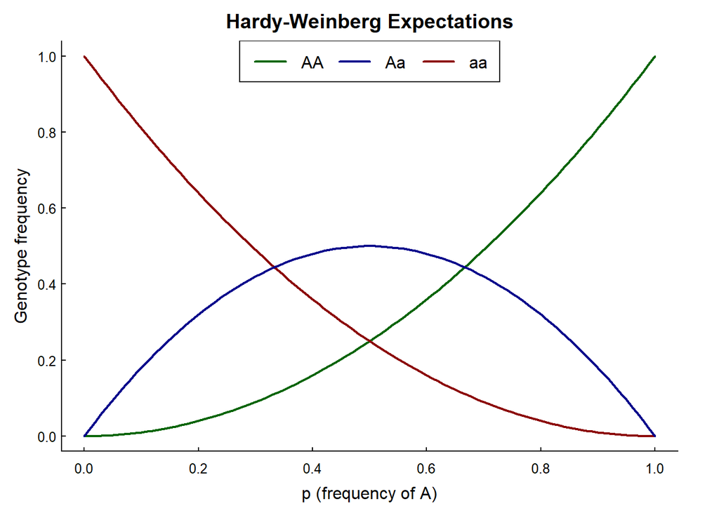

```r
curve(x^2, lwd = 2, col = "darkgreen", xlab = "p (frequency of A)",
      ylab = "Genotype frequency", main = "Hardy-Weinberg Expectations")
curve((1-x)^2, lwd = 2, col = "darkred", add = TRUE)
curve(2*x*(1-x), lwd = 2, col = "darkblue", add = TRUE)
legend("top", legend = c("AA", "Aa", "aa"),
       col = c("darkgreen", "darkblue", "darkred"), lwd = 2, horiz = TRUE)
```

The key insight: heterozygotes (blue) are maximized at $p = 0.5$, while homozygotes dominate at extreme allele frequencies.

## 2. Simulating Random Mating

Under HWE assumptions, offspring genotypes arise from random union of gametes. We can simulate this by:

1. Creating a pool of diploid males, each carrying two alleles sampled according to frequency $p$
2. Creating a pool of diploid females the same way
3. Each parent contributes one randomly chosen allele to offspring

```r
p <- 0.8  # frequency of A allele
N <- 100  # population size

# Each row is an individual with 2 alleles
Males <- matrix(sample(c("A","a"), size = N*2,
                       replace = TRUE, prob = c(p, 1-p)), nrow = N)

Females <- matrix(sample(c("A","a"), size = N*2,
                         replace = TRUE, prob = c(p, 1-p)), nrow = N)

# Each parent contributes one allele (randomly from their two)
NextGen <- cbind(apply(Males, 1, sample, 1),
                 apply(Females, 1, sample, 1))

# Sort alleles so "aA" and "Aa" both become "aA"
genotypes <- c("aa", "aA", "AA")

f.genotype <- apply(NextGen, 1, sort) |>
  apply(2, paste, collapse = "") |>
  factor(levels = genotypes) |>
  table() |> prop.table()

f.genotype
```

```
##
##   aa   aA   AA
## 0.02 0.28 0.70
```

## 3. Creating a Simulation Function

We wrap this into a reusable function:

```r
simFrequencies <- function(p, n = 100){
  Males <- matrix(sample(c("A","a"), size = n*2,
                         replace = TRUE, prob = c(p, 1-p)), nrow = n)

  Females <- matrix(sample(c("A","a"), size = n*2,
                           replace = TRUE, prob = c(p, 1-p)), nrow = n)

  NextGen <- cbind(apply(Males, 1, sample, 1),
                   apply(Females, 1, sample, 1))

  genotypes <- c("aa", "aA", "AA")

  f.genotype <- apply(NextGen, 1, sort) |>
    apply(2, paste, collapse = "") |>
    factor(levels = genotypes) |>
    table() |> prop.table()

  return(f.genotype)
}
```

Test it at the same frequency, to see sampling variation:

```r
simFrequencies(0.2, 100)
```

```
##
##   aa   aA   AA
## 0.60 0.35 0.05
```

```r
simFrequencies(0.2, 100)
```

```
##
##   aa   aA   AA
## 0.69 0.28 0.03
```

```r
simFrequencies(0.2, 100)
```

```
##
##   aa   aA   AA
## 0.56 0.34 0.10
```

And at a different frequency:

```r
simFrequencies(0.8, 100)
```

```
##
##   aa   aA   AA
## 0.01 0.30 0.69
```

```r
simFrequencies(0.8, 100)
```

```
##
##   aa   aA   AA
## 0.02 0.40 0.58
```

```r
simFrequencies(0.8, 100)
```

```
##
##   aa   aA   AA
## 0.04 0.30 0.66
```

> **Note:** It is not important (for now) to understand *how* the function works - just that you enter the allele frequency and sample size, and that it returns genome frequencies.

## 4. Visualizing Sampling Variation

Even when HWE holds exactly, finite samples show variation around expected values. Let’s simulate across many allele frequencies and overlay the results on the theoretical curves:

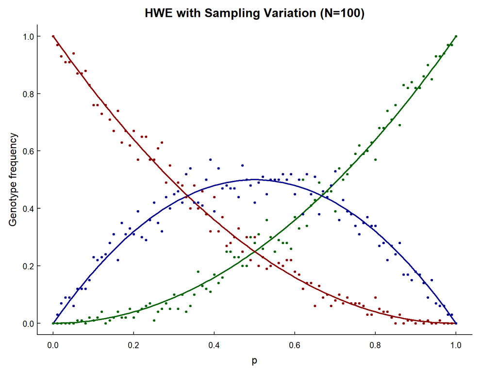

```r
cols <- c(AA = "darkgreen", aA = "darkblue", aa = "darkred")

curve(x^2, lwd = 2, col = "darkgreen", xlab = "p",
      ylab = "Genotype frequency", main = "HWE with Sampling Variation (N=100)")
curve((1-x)^2, lwd = 2, col = "darkred", add = TRUE)
curve(2*x*(1-x), lwd = 2, col = "darkblue", add = TRUE)

for(p in seq(0, 1, 0.01)){
  f.obs <- simFrequencies(p, n = 100)
  points(rep(p, length(f.obs)), f.obs, col = cols[names(f.obs)], pch = 19, cex = 0.5)
}
```

The scatter around the curves shows sampling variance — this is what we expect even when HWE is true.

## 5. Testing HWE with Daphnia PGM Data

Now we apply this to real data. From Spitze (1993), the PGM locus genotype counts in *Daphnia obtusa* were:

| Genotype | Count |
| --- | --- |
| MM | 57 |
| MS | 53 |
| SS | 18 |

- At the PGM locus: M = “medium”, S = “slow”.
- Using our notation: A = M (medium), a = S (slow)

```r
c_aa <- 18   # SS
c_aA <- 53   # MS
c_AA <- 57   # MM

N <- c_aa + c_aA + c_AA
freq.obs <- c(aa = c_aa, aA = c_aA, AA = c_AA) / N

# Calculate allele frequencies from the data
p <- (c_AA + c_aA/2) / N  # frequency of M allele
q <- (c_aa + c_aA/2) / N  # frequency of S allele
```

note, of course, these sum to 1

```r
p
```

```
## [1] 0.6523438
```

```r
q
```

```
## [1] 0.3476562
```

```r
p+q
```

```
## [1] 1
```

### Observed vs. Expected

To **test** whether a population conforms to the Hardy-Weinburg null model, we need to compare **observations** to a **null prediction**. This is at the heart of all statistical tests. We gather those as follows:

```r
counts.obs <- c(aa = c_aa, aA = c_aA, AA = c_AA)
counts.exp <- N * c(aa = q^2, aA = 2*p*q, AA = p^2)

rbind(Observed = counts.obs, Expected = round(counts.exp, 1))
```

```
##            aa   aA   AA
## Observed 18.0 53.0 57.0
## Expected 15.5 58.1 54.5
```

The classical approach uses a **chi-squared goodness-of-fit test**. The test statistic quantifies how far observed counts deviate from expected counts, scaled by the expected values:

$$\chi^2 = \sum_i \frac{(O_i -
E_i)^2}{E_i}$$

We can compute this directly from our data:

```r
chi_sq_test <- sum((counts.obs - counts.exp)^2 / counts.exp)
chi_sq_test
```

```
## [1] 0.9717097
```

The scaling by $E_i$ in the denominator matters: a deviation of 5 individuals is more surprising when you expected 10 than when you expected 100. The squaring ensures positive and negative deviations don’t cancel out.

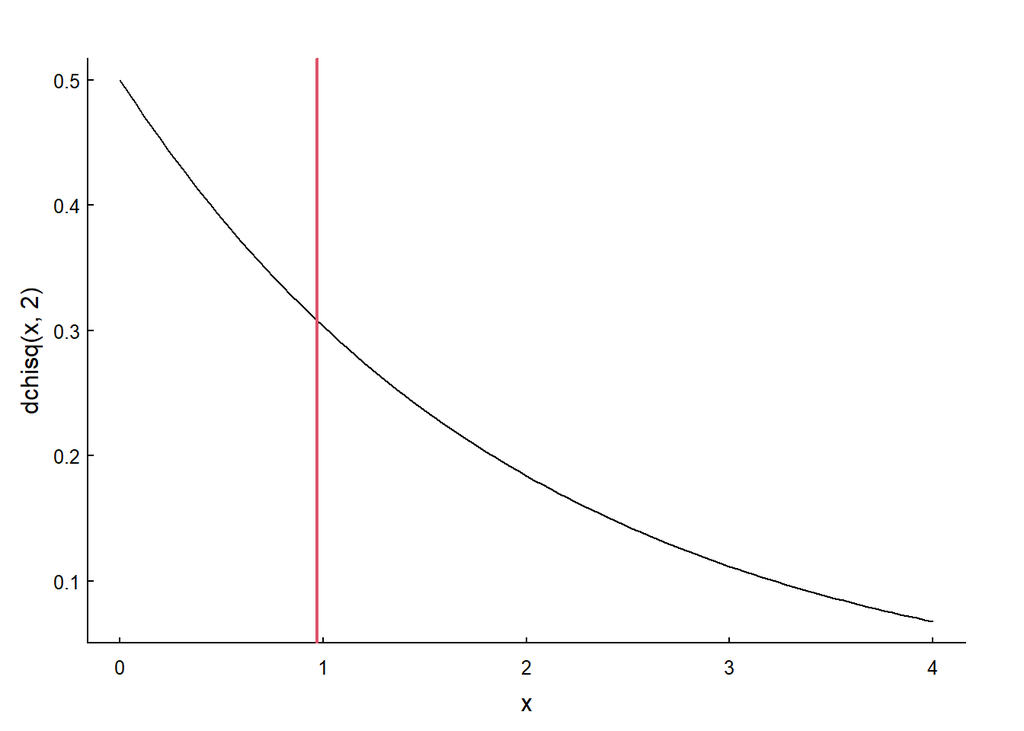

```r
curve(dchisq(x,2), xlim = c(0,4))
abline(v = chi_sq_test, col = 2, lwd = 2)
```

It is not *very* extreme. A measure of that *not very extremeness* is the *p*-value, which is the area under that curve to the right of the test statistic:

```r
1- pchisq(chi_sq_test, 2)
```

```
## [1] 0.6151711
```

All of this, of course, is done more or less immediately with an R function:

```r
chisq.test(counts.obs, p = c(q^2, 2*p*q, p^2))
```

```
##
##  Chi-squared test for given probabilities
##
## data:  counts.obs
## X-squared = 0.97171, df = 2, p-value = 0.6152
```

So - clearly - a highly non-significant devaition.

This is a straightforward, simple, robust, and very common approach. However, it does rely on some assumptions and convoluted reasoning and the blank stare when you present to someone the very concept of a *test-statistic*. In a modern age where computations are trivial, we might try a more intuitive approach.

### Randomization Test of Heterozygote Deviation

Since we can simply simulate this process directly from a population of the correct size with the correct allele frequencies, we can also ask directly: *is the observed proportion of heterozygotes in excess or in defecit of the Hardy-Weinberg expectations?* The steps are to:

1. Genearte a null distribution by simulation
2. Compare the observed values *directly* against the null.

We generate a null distribution by simulation. This step will take a (noticable) few seconds:

```r
nsims <- 1000
genotype_sims <- matrix(NA, nrow = nsims, ncol = 3)
colnames(genotype_sims) <- c("aa", "aA", "AA")

for(i in 1:nsims)
  genotype_sims[i,] <- simFrequencies(p, N)
```

Note what we computed here:

```r
head(genotype_sims)
```

```
##             aa        aA        AA
## [1,] 0.1250000 0.4609375 0.4140625
## [2,] 0.1328125 0.4843750 0.3828125
## [3,] 0.0937500 0.4296875 0.4765625
## [4,] 0.1640625 0.4296875 0.4062500
## [5,] 0.1250000 0.3906250 0.4843750
## [6,] 0.1093750 0.4531250 0.4375000
```

A bunch of sets (1000) of proportions. We can look at those distributions against our observations as follows.

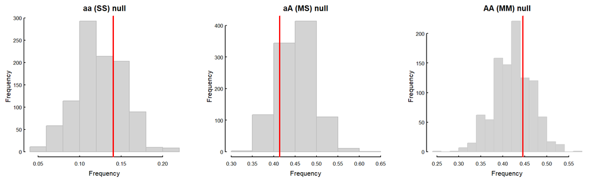

```r
par(mfrow = c(1, 3))

hist(genotype_sims[,"aa"], main = "aa (SS) null",
     xlab = "Frequency", border = "gray")
abline(v = freq.obs["aa"], lwd = 2, col = "red")

hist(genotype_sims[,"aA"], main = "aA (MS) null",
     xlab = "Frequency", border = "gray")
abline(v = freq.obs["aA"], lwd = 2, col = "red")

hist(genotype_sims[,"AA"], main = "AA (MM) null",
     xlab = "Frequency", border = "gray80")
abline(v = freq.obs["AA"], lwd = 2, col = "red")
```

Red lines show observed values. Since they are not too “extreme” - most likely this is a totally reasonable draw from Hardy-Weinberg proportions.

### Computing empirical P-values

For the randomization test we directly ask: how often do simulated heterozygote frequencies fall below the observed value (suggesting heterozygote deficit)?

```r
# Two-tailed p-value for heterozygotes
(p_value_hetero <- sum(genotype_sims[,"aA"] < freq.obs["aA"]) / nsims)  * 2
```

```
## [1] 0.324
```

> **TRICKY EXERCISE:** think a bit about why this works … why `sum`? why `/ nsims`? why the `<`? why `*2`? This is correct - but it only works because we can see that the observed frequency is slightly lower than the mean. How would you compute a p-value if you didn’t know whether it was greater or smaller than that mean?

Equivalently, we can test for homozygote excess (which is the inverse):

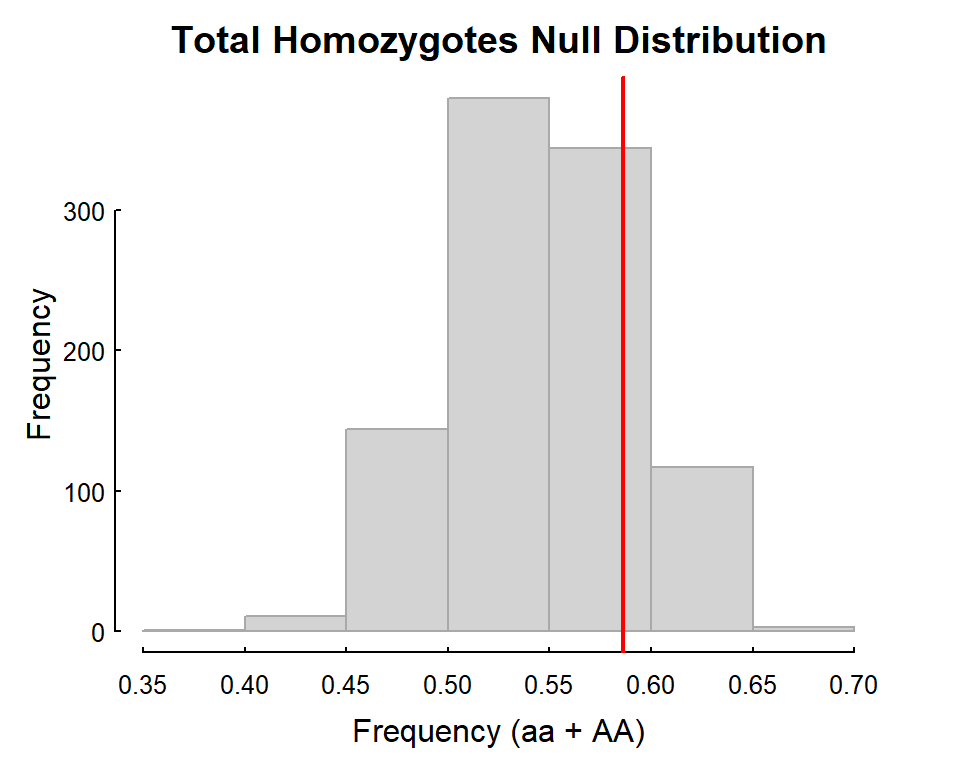

```r
homo_null <- genotype_sims[,"aa"] + genotype_sims[,"AA"]
homo_obs <- freq.obs["aa"] + freq.obs["AA"]

par(mfrow = c(1, 1))
hist(homo_null, main = "Total Homozygotes Null Distribution",
     xlab = "Frequency (aa + AA)", border = "darkgrey")
abline(v = homo_obs, lwd = 2, col = "red")
```

```r
(p_value_homo <- sum(homo_null > homo_obs) / nsims * 2)
```

```
## [1] 0.324
```

These two p-values should be equivalent — heterozygote deficit *is* homozygote excess.

### Interpretation

Both approaches test the same hypothesis. The randomization test makes fewer assumptions about the sampling distribution and directly uses simulation to generate the null. The chi-squared test assumes the test statistic follows a $\chi^2$ distribution (valid for large samples).

For this dataset, the observed genotype frequencies are consistent with Hardy-Weinberg expectations — we find no significant evidence of heterozygote deficit or homozygote excess at the PGM locus.

# Homework Assignment

**For these assignments - we do NOT want to see code! Just provide the answers - including figures - in a document.**

In the same study, [Spitz 1993](https://pmc.ncbi.nlm.nih.gov/articles/PMC1205642/pdf/ge1352367.pdf), also studied the PGI locus, with two alleles: S+ and S-, with these these ratios:

```
Allele | Count
----------------
SS     | 42
SS-    | 48
S-S-   | 38
```

1. What are the expected Hardy Weinberg proportions of the *alleles*
2. What are the expected counts of the *genotypes*?
3. Perform a chi-squared test of consistency with the expected proportions. Visualize that test along the lines of the code above.
4. Perform a randomization test of heterozygote excess or defecit. Visualize that test along the lines of the code above.

Discuss (briefly).

**Extra credit - pure algebrea:** Under HWE, at what values of *p* does the number of heterozygotes exceed the number of both homozygotes? At what values of *p* does the number of exceed TOTAL number of homozygotes?